# Examplary application of `papros`

Wolfgang Hamer

20 Februar 2019

## Data preparation

### Climate Data

#### First the required librarys

```r
library(papros)
library(magrittr)
library(tidyr)
```

#### Download of weather data

Now we can download the weather data, which are interesting for the prediction of the pathogen powdery mildew. The weather data are separated in historical data and recent data. The historical data reach longer in the past and are no longer updated in contradiction to the recent data.

```r
if(!file.exists("./data/rdsfiles/hist_weath_sh.rds")){
  hist_weath_sh <- download_statewide_hourly_station_data(state = "Schleswig-Holstein",
                                                        time = "historical",
                                                        coord = TRUE)

  saveRDS(hist_weath_sh, "./data/rdsfiles/hist_weath_sh.rds")
}else{
  hist_weath_sh <- readRDS("./data/rdsfiles/hist_weath_sh.rds")
}

if(!file.exists("./data/rdsfiles/rec_weath_sh.rds")){
  rec_weath_sh <- download_statewide_hourly_station_data(state = "Schleswig-Holstein",
                                                        time = "recent",
                                                        coord = TRUE)

  saveRDS(rec_weath_sh, "./data/rdsfiles/rec_weath_sh.rds")
}else{
  rec_weath_sh <- readRDS("./data/rdsfiles/rec_weath_sh.rds")
}

weath_sh <- rbind(hist_weath_sh, rec_weath_sh) %>%
  dplyr::distinct()
```

#### Reduce dataset and calculate Cumulative Thermal Unit

```r
if(!file.exists("./data/rdsfiles/weath_sh.rds")){
  weath_sh %<>% dplyr::filter(DateTime > 1995093023) %>%
    dplyr::mutate(Date = as.Date(substr(DateTime,1,8),"%Y%m%d")) %>%
    dplyr::mutate(CTU = large_ctu(dataset = .,
                                  temp_column = "Temperature",
                                  date_column = "Date",
                                  start_date = "10-01",
                                  location_column = "ID")) %>%
    dplyr::select(-Date)

  saveRDS(weath_sh, "./data/rdsfiles/weath_sh.rds")
}else{
  weath_sh <- readRDS("./data/rdsfiles/weath_sh.rds")
}


head(weath_sh)
```

```
##   ID   DateTime Temperature Humidity Precipitation WindSpeed WindDirection
## 1 52 1995100100          NA       NA            NA       1.0           270
## 2 52 1995100101          NA       NA            NA       1.5           270
## 3 52 1995100102          NA       NA            NA       1.5           270
## 4 52 1995100103          NA       NA            NA       2.0           280
## 5 52 1995100104          NA       NA            NA       2.0           280
## 6 52 1995100105          NA       NA            NA       1.5           280
##       lat    lon CTU
## 1 53.6623 10.199  NA
## 2 53.6623 10.199  NA
## 3 53.6623 10.199  NA
## 4 53.6623 10.199  NA
## 5 53.6623 10.199  NA
## 6 53.6623 10.199  NA
```

#### Download multi annual DWD data in the area of interest

In addition to the hourly weahter data we downloaded before, we add some multi-annual climate data, since we assume, that this also influences the spread of the pathogen.

```r
library(raster)
if(!file.exists("./data/rdsfiles/coraster.rds")){
  germ <- raster::getData('GADM', country='DEU', level=1)
  sh <- germ[which(germ$NAME_1=="Schleswig-Holstein"),]

  coraster <- raster::stack(download_dwd_raster(parameter = "air_temperature_mean", period = "1961-1990", month = 17, crop=sh),
                            download_dwd_raster(parameter = "precipitation", period = "1961-1990", month = 17, crop=sh),
                            download_dwd_raster(parameter = "water_balance", period = "1961-1990", month = 17, crop=sh))

  coraster <- raster::projectRaster(coraster,crs=CRS("+init=epsg:25832"))
  saveRDS(coraster, "./data/rdsfiles/coraster.rds")
}else{
  coraster <- readRDS("./data/rdsfiles/coraster.rds")
}

library(mapview)
mapview(coraster[[1]])+mapview(coraster[[2]])+mapview(coraster[[3]])
```

[interactive chart not shown]

### Infestation Data

Now we include the infestation data and create a `SpatialPointsDataFrame` of them.

```r
library(sp)
inf_dat <- read.csv2("./data/raw_data/spatial/infestation_data_2.csv") %>%
  dplyr::mutate(Date = as.Date(as.character(Date,"%Y-%m-%d")))
head(inf_dat)
```

```
##   Location        x       y       Date Infection_PM Infection_BR
## 1    Barlt 501463.9 5985602 1995-05-22          0.0            0
## 2    Barlt 501463.9 5985602 1995-04-24          0.0            0
## 3    Barlt 501463.9 5985602 1995-05-01          0.0            0
## 4    Barlt 501463.9 5985602 1995-05-08          0.0            0
## 5    Barlt 501463.9 5985602 1995-05-15          0.0            0
## 6    Barlt 501463.9 5985602 1996-06-10         63.3            0
```

```r
inf_dat_sp <- SpatialPointsDataFrame(coords = inf_dat[,c("x","y")],
                                     data = inf_dat,
                                     proj4string = CRS(("+init=epsg:25832")))

# Remove duplicated locations for interpolation
inf_dat_sp_single <- inf_dat_sp[!duplicated(inf_dat_sp$Location),-c(5,6)]

# Add Covariable raster data
inf_dat_sp_single <- raster::extract(coraster,inf_dat_sp_single,sp=TRUE)

inf_dat_sp_single
```

```
## class       : SpatialPointsDataFrame
## features    : 12
## extent      : 491597.4, 643556.4, 5957153, 6054210  (xmin, xmax, ymin, ymax)
## coord. ref. : +init=epsg:25832 +proj=utm +zone=32 +ellps=GRS80 +towgs84=0,0,0,0,0,0,0 +units=m +no_defs
## variables   : 7
## names       :          Location,        x,       y,       Date, air_temp_mean_1961.1990_17, precipitation_1961.1990_17, water_balance_1961.1990_17
## min values  :             Barlt, 491597.4, 5957153, 1995-04-24,                   81.00000,                   575.8416,                  -4.074289
## max values  : Sönke-Nissen-Koog, 643556.4, 6054210, 1996-05-06,                   85.88474,                   826.9701,                 256.541322
```

## Powdery Mildew Prediction

### Interpolate an aggregate weather for monitoring locations

For the prediction of the infestations we need to know, how the weather was at the locations we now about. Therefore we need to interoplate the weahter data. In this example we tell the function `aggregate_interpolate_points` to interpolate all wehater parameters trying Ordinary Kriging and if this should not work, trying Inverse Distance Weighting. Of course, for only one interoplation we would manually create and fit a nice variogram, but remeber that we have hourly weather data of 20 years! Therfore we use automated fitting algorithms.Also in this step included is the aggregation and reduction of the dataset. The function `reduce_input` only selects weahter data of the dates, relevant for our infestation data. But why do we use this specific function? Because we assume a temporal difference between the observation of the infestation (the incubation period) and the time span (infection period) during which the weather was important for the infestation. Therefore these parameters are included in the functions as well.

```r
if(!file.exists("./data/rdsfiles/weath_sh_pm_int.rds")){
  # How many interpolations would be carried out?
  length(unique(weath_sh$DateTime))
  # Still quite large, better to reduce the dataset to the times relevant for the infestation by powdery mildew:
  weath_sh_pm <- reduce_input(dataframe = weath_sh,
                              DateTime = "DateTime",
                              infection = 2,
                              incubation = 8,
                              event_dates = inf_dat$Date)

  length(unique(weath_sh_pm$DateTime))

  weath_sh_pm_int <- aggregate_interpolate_points(dataframe = weath_sh_pm,
                                                  coords = c("lon","lat"),
                                                  DateTime = "DateTime",
                                                  infection=2,
                                                  incubation=8,
                                                  aim_variable =c("Temperature","Humidity","Precipitation","WindSpeed","CTU"),
                                                  outputfile=inf_dat_sp_single,
                                                  co_variables = FALSE,
                                                  procedure = c("ok","idw"),
                                                  epsg = 4326,
                                                  trans_epsg = 25832)
  saveRDS(weath_sh_pm_int, "./data/rdsfiles/weath_sh_pm_int.rds")
}else{
  weath_sh_pm_int <- readRDS("./data/rdsfiles/weath_sh_pm_int.rds")
}
```

### Create combined dataframe

After interpolation we combine the interpolated and aggregated weather data and the infestation data.

```r
if(!file.exists("./data/rdsfiles/pm_dieas_weath.rds")){
  pm_dieas_weath <- do.call("rbind",Map(function(x){x@data},x=weath_sh_pm_int)) %>%
    dplyr::mutate(Date = as.Date(Date,"%Y%m%d")) %>%
    dplyr::inner_join(inf_dat, by=c("x","y","Date"))
  saveRDS(pm_dieas_weath, "./data/rdsfiles/pm_dieas_weath.rds")
}else{
  pm_dieas_weath <- readRDS("./data/rdsfiles/pm_dieas_weath.rds")
}

head(pm_dieas_weath)
```

```
##          x       y Location.x       Date air_temp_mean_1961.1990_17
## 1 501463.9 5985602      Barlt 1996-05-06                   82.02993
## 2 568733.7 6032253 Birkenmoor 1996-05-06                   83.02643
## 3 534391.2 5962184     Elskop 1996-05-06                   84.05234
## 4 643556.4 6037650    Fehmarn 1996-05-06                   83.91584
## 5 606426.2 6017214 Futterkamp 1996-05-06                   84.96794
## 6 602845.9 5957153    Kastorf 1996-05-06                   82.94788
##   precipitation_1961.1990_17 water_balance_1961.1990_17      x.1     y.1
## 1                   826.9701                 253.942861 501463.9 5985602
## 2                   745.6341                 212.458408 568733.7 6032253
## 3                   784.9020                 224.867630 534391.2 5962184
## 4                   575.8416                  -4.074289 643556.4 6037650
## 5                   649.4213                 114.492959 606426.2 6017214
## 6                   703.5854                 128.726482 602845.9 5957153
##   Temperature_mean Temperature_min Temperature_max Humidity_mean
```

[output cut: 27 more lines]

### Create machine learning model

Then we let the machine (here the Random Forest algorithm) learn under which circumstances dangerous events (defined by us as disease incidence larger than 70) occured. By now I did not include the enhancement methods I created during my [thesis](https://macau.uni-kiel.de/receive/dissertation_diss_00023094), but this will happen soon.

```r
pm_dieas_weath %<>% na.omit() %>%
  dplyr::mutate(Danger = Infection_PM) %>%
  dplyr::mutate(Danger = as.factor(ifelse(Danger<70,0,1)))

rf_pred_pm <- machine_learner(dataframe=pm_dieas_weath,
                           aim_variable="Danger",
                           co_variables=c("Temperature_mean","Temperature_min","Temperature_max",
                                          "Humidity_mean","Humidity_min","Humidity_max",
                                          "Precipitation_mean","Precipitation_min","Precipitation_max",
                                          "WindSpeed_mean","WindSpeed_min","WindSpeed_max","air_temp_mean_1961.1990_17",
                                          "precipitation_1961.1990_17","water_balance_1961.1990_17","CTU_mean"),
                           method = "RF")
```

### Spatio-temporal prediction

To create spatio-temporal predictions we interpolate the weather data of some days not only for some points but for the whole area of Schleswig-Holstein and use the `machine_predictor` to predict the model generated using the `machine_learner` on the raster stacks.

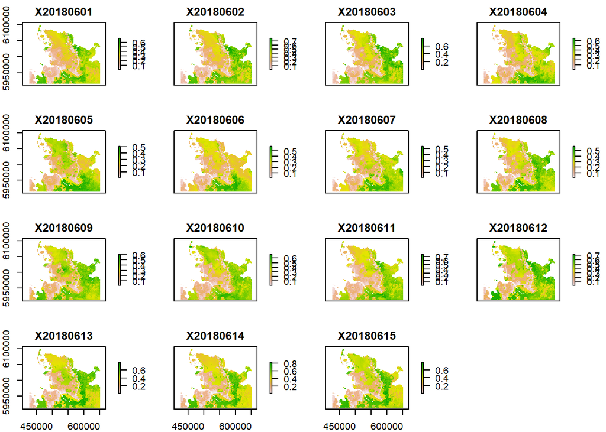

```r
# Lets try a spatial prediction for some days
rec_weath_sh <- readRDS("./data/rdsfiles/rec_weath_sh.rds")
rec_weath_sh %<>% dplyr::mutate(Date = as.Date(substr(DateTime,1,8),"%Y%m%d")) %>%
  dplyr::mutate(CTU = large_ctu(dataset = .,
                                temp_column = "Temperature",
                                date_column = "Date",
                                start_date = "10-01",
                                location_column = "ID")) %>%
  dplyr::select(-Date) %>%
  reduce_input(dataframe = .,
               DateTime = "DateTime",
               infection = 2,
               incubation = 8,
               event_dates = seq(from = as.Date("2018-06-01","%Y-%m-%d"),
                                 to = as.Date("2018-06-15","%Y-%m-%d"),
                                 by = 1))


if(!dir.exists("./data/rdsfiles/pred_weath_sh_pm_int")){
  pred_weath_sh_pm_int <- aggregate_interpolate_points(dataframe = rec_weath_sh,
                                                       coords = c("lon","lat"),
                                                       DateTime = "DateTime",
                                                       infection=2,
                                                       incubation=8,
                                                       aim_variable =c("Temperature","Humidity","Precipitation","WindSpeed","CTU"),
                                                       outputfile=coraster[[1]],
                                                       co_variables = FALSE,
                                                       procedure = c("ked","ok","idw"),
                                                       epsg = 4326,
                                                       trans_epsg = 25832)
  store_rasterstacklist(rstacklist = pred_weath_sh_pm_int,
                      pathfolder = "./data/rdsfiles/pred_weath_sh_pm_int")
}else{
  pred_weath_sh_pm_int <- read_rasterstacklist(pathfolder = "./data/rdsfiles/pred_weath_sh_pm_int")
}

pm_predicted_stack <- machine_predictor(rstack = pred_weath_sh_pm_int,
                                        mmodel = rf_pred_pm$RF,
                                        additionalRaster = coraster,
                                        type = "prob",
                                        index = 2)

plot(pm_predicted_stack)
```

### Create video from predicted stack

The `videoplot_rasterstack` allows us to use the animation package (which itself uses ffmpeg) to creat a nice video of our predictions.

```r
videoplot_rasterstack(rstack = pm_predicted_stack,
                      ffmpeg_path = paste0(getwd(),"/data/ffmpeg-20150911-git-f58e011-win64-static/bin/ffmpeg.exe"),
                      storefile = "./plots/powdery_mildew_pred.mp4",
                      col=colorRampPalette(c("#1a9850","#66bd63","#a6d96a","#d9ef8b","#fee08b","#fdae61","#f46d43","#d73027"))(8))
```

```r
library(shinyLP)
iframe(width = "415", height = "415",
url_link = "./plots/powdery_mildew_pred.mp4")
```

[interactive chart not shown]

### PLZ specific predictions

The `machine_predictor_lineplot` allows location specific plots for points and polygons:

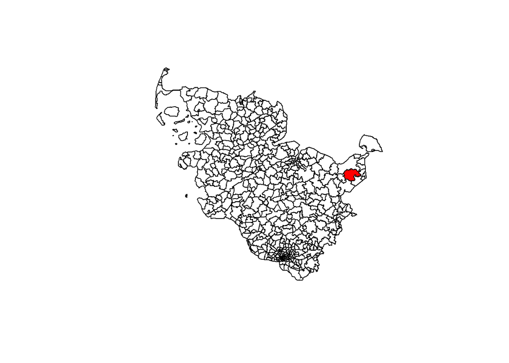

```r
library(sf)
library(ggplot2)
plz <- read_sf("./data/raw_data/spatial/plz5sh-stellig.gpkg") %>%
  as(.,"Spatial")

se <- 155

plot(plz)
plot(plz[se,],add=TRUE,col="red")
```

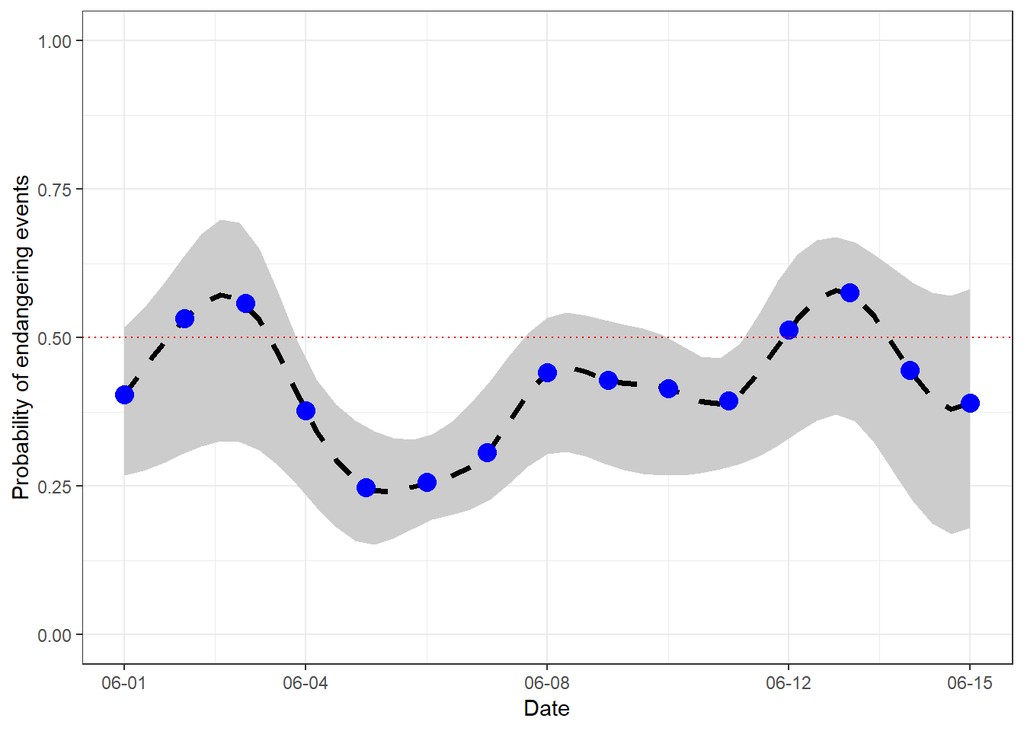

```r
machine_predictor_lineplot(rstack = pm_predicted_stack,
                           location = plz[se,],
                           yname ="Probability of endangering events",
                           ylim=c(0,1),
                           rollingaverage = 1,
                           threshold = 0.5)
```